# Otimização Operacional [VITA] .alpha

Ícaro Agostino

18/05/2020

### API para Otimização Operacional caso VITA

Esse documento descreve a API desenvolvida para Otimização Operacional do caso VITA, o objetivo principal dessa aplicação é fornecer um modelo para alocação da montagem de ventiladores, assim como para a produção das partes e transporte.

A aplicação foi separada em duas partes:

- **Alocação do Centro de Montagem**: a escolha do centro de montagem final para os ventilador baseada no tempo total entre a montagem e entrega final.
- **Alocação da Produção das Partes**: a escolha da célula de produção final de cada parte do ventilador baseado no tempo total entre a produção de cada parte e a entrega para montagem.

Dessa forma, a aplicação foi implementada utilizando a arquitetura **REST** em conjunto com o *framework* [**swagger**](https://swagger.io/).

[figure not shown]

Essa versão inicial da aplicação está hospedada em uma máquina virtual da AWS e pode ser consultada no link:

- **http://ec2-18-231-56-101.sa-east-1.compute.amazonaws.com:8888/__swagger__/**

## 1. Alocação do Centro de Montagem

O modelo de alocação desenvolvido foi adaptado do projeto [FASTEN](http://www.fastenmanufacturing.eu/). A otimização realizada executa um algorítimo de busca exaustiva considerando todas as opções disponíveis dentro de um espaço amostral definido. Além dos dados consumidos pela aplicação via sistema web, foi utilizado para o calculo e estimação dos tempos de transporte a API externa do [**Open Route Service**](https://openrouteservice.org/), sendo uma aplicação *open source* para geolocalização, permitindo estimar tempos de transporte de forma dinâmica entre múltiplas localizações.

A escolha do centro de montagem final para os ventilador é definida baseada na otimização local do tempo total de **fila** e **transporte** entre os centros de montagens disponíveis e o local final de entrega do produto.

[figure not shown]

Para a implementação da aplicação foram gerados dados randomizados. Na aplicação futura integrada ao sistema de gestão esses dados devem ser consultados em um banco de dados fornecido pelo sistema web.

**Geolocalização e *status* dos centros de montagem:**

[output not shown]

Para os dados gerados acima foi definido um nome para cada centro, nesse caso utilizamos o nome da cidade por conveniência. O *status* operacional, que nesse caso inicial foi definido “ON” para todos os centros, indicando que estão disponíveis para receber uma ordem de montagem. O tempo estimado de fila que deve ser fornecido pelo sistema. E a geolocalização dos centros de montagem, definida pelas coordenadas geográficas.

### 1.1 Dados de entrada

Para a **Alocação do Centro de Montagem** foram definidos para essa versão os seguintes inputs:

- **produto**: tipo de produto a ser montado no centro.
- **qtd**: quantidade o produto a ser montado no centro.
- **lon**: longitude do local de entrega do produto final.
- **lat**: latitude do local de entrega do produto final.
- **orderID**: um identificador para a ordem de montagem, nesse caso deve ser uma *string* única enviada pelo sistema ou usuário da aplicação. O identificador é retornado como parte do objeto de saída.

Um exemplo de entrada em **.json** para uma requisição de alocação de montagem será:

```
{
  "orderID": "2ad1ee0d-ee75-4dab-a27c-e356be6776ee",
  "produto": "ventilador tipo 1",
  "qtd": 4,
  "lon": -46.2903,
  "lat": -23.8647
}
```

### 1.2 Execução e saída

Para realizar a alocação de montagem deve ser utilizado o método **POST** passando como entrada a **url** onde a aplicação está hospedada e os dados de entrada apresentados anteriormente. Graficamente utilizando o *swagger* da aplicação podemos realizar a requisição:

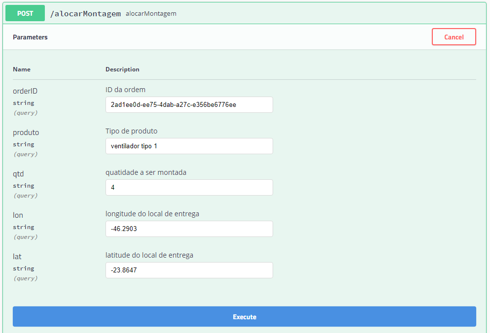

O resultado terá como saída uma lista ranqueada com as 5 opções que retornaram menor tempo total de **fila** e **transporte** entre o local final e os centros disponíveis. O objeto de saída será um **.json**, para o exemplo acima o resultado será:

```
{
  "orderInfo": {
    "orderID": "2ad1ee0d-ee75-4dab-a27c-e356be6776ee",
    "produto": "ventilador tipo 1",
    "quantitade": "4"
  },
  "resultado": [
    {
      "centroMontagem": "SANTOS",
      "tempoFila": 112.9523,
      "tempoViagem": 2189.62,
      "tempoTotal": 2302.5723
    },
    {
      "centroMontagem": "SANTO ANDRE",
      "tempoFila": 90.3287,
      "tempoViagem": 4550.32,
      "tempoTotal": 4640.6487
    },
    {
      "centroMontagem": "SAO PAULO - CENTRAL NORTE",
      "tempoFila": 101.0418,
      "tempoViagem": 4925.17,
      "tempoTotal": 5026.2118
    },
    {
      "centroMontagem": "SANTO AMARO",
      "tempoFila": 109.3473,
      "tempoViagem": 4925.17,
      "tempoTotal": 5034.5173
    },
    {
      "centroMontagem": "JABAQUARA",
      "tempoFila": 87.2621,
      "tempoViagem": 5065.23,
      "tempoTotal": 5152.4921
    }
  ]
}
```

## 2. Alocação da Produção das Partes

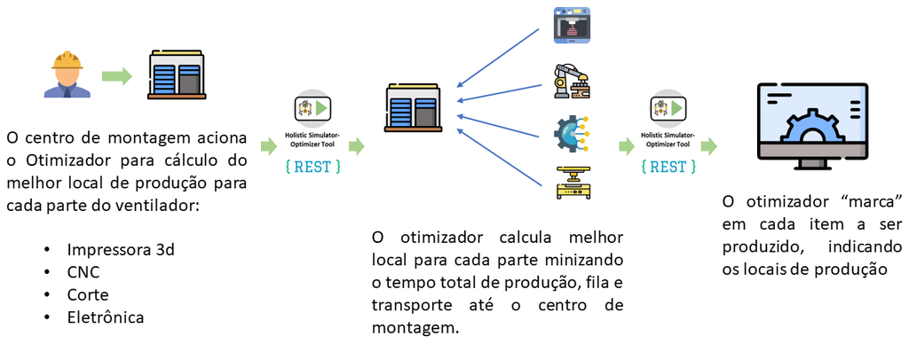

Para a implementação da aplicação, assim como no caso anterior, foram gerados dados randomizados que na aplicação devem ser consultados em um banco fornecido pelo sistema web.

**Geolocalização, tipo e *status* das células de produção:**

```
## # A tibble: 58 x 6
##    tipo    celName       status  fila latitude longitude
##    <chr>   <chr>         <chr>  <dbl>    <dbl>     <dbl>
##  1 Eletro  SAO PAULO     ON     102.    -23.6      -46.6
##  2 CNC     CURITIBA      ON      79.0   -25.5      -49.3
##  3 print3d BRASILIA      ON      90.5   -15.8      -47.9
##  4 print3d RECIFE        ON     106.     -8.06     -34.9
##  5 Corte   FLORIANOPOLIS ON      95.7   -27.6      -48.5
##  6 Eletro  SALVADOR      ON      92.1   -13.0      -38.4
##  7 Eletro  FORTALEZA     ON     115.     -3.74     -38.5
##  8 Corte   GOIANIA       ON      98.9   -16.7      -49.3
##  9 print3d NITEROI       ON      92.5   -22.9      -43.1
## 10 print3d MANAUS        ON     118.     -3.13     -60.0
```

Para os dados gerados acima, assim como na montagem, foi definido um nome para cada célula, assim como especificado o tipo de tarefa que essa célula está habilitada a relizar (Ex.: impressão 3d, CNC, eletrônica e etc). Os demais valores correspondem ao *status*, tempo estimado de fila e geolocalização.

**Tempo padrão de execução de cada atividade:**

```
## # A tibble: 20 x 2
##    part       time
##    <fct>     <dbl>
##  1 pr1    458.
##  2 pr2    617.
##  3 pr3    695.
##  4 pr4    152.
##  5 pr5     19.6
##  6 cn1    786.
##  7 cn2    180.
##  8 cn3    883.
##  9 cn4   1614.
## 10 cn5    546.
## 11 ct1     16.5
## 12 ct2   1028.
## 13 ct3    475.
## 14 ct4      0.0571
## 15 ct5    702.
## 16 el1     74.0
## 17 el2   1368.
## 18 el3    151.
## 19 el4    353.
## 20 el5    183.
```

Para os dados gerados acima foram criados 20 partes fictícias como exemplo e randomizado o tempo de execução utilizando uma distribuição exponencial com 500 minutos de média.

### 2.1 Dados de entrada

Para a **Alocação da Produção das Partes** foram definidos para essa versão os seguintes inputs:

- **tipoServ**: tipo de serviço a ser executado (Ex.: impressão 3d, CNC, eletrônica e etc).
- **parte**: tipo de produto a ser produzido na célula.
- **qtd**: quantidade o produto a ser montado no centro.
- **lon**: longitude do local de entrega do produto final.
- **lat**: latitude do local de entrega do produto final.
- **orderID**: um identificador para a ordem de produção, nesse caso deve ser uma *string* única enviada pelo sistema ou usuário da aplicação. O identificador é retornado como parte do objeto de saída.

Um exemplo de entrada em **.json** para uma requisição de alocação de montagem será:

```
{
  "orderID": "2ad1ee0d-ee75-4dab-a27c-e356be6776ee",
  "tipoServ": "print3d",
  "parte": "pr2",
  "qtd": 3,
  "lon": -46.2903,
  "lat": -23.8647
}
```

### 2.2 Execução e saída

Para realizar de alocação da produção deve ser utilizado o método **POST** passando como entrada a **url** onde a aplicação está hospedada e os dados e entrada apresentados anteriormente. Graficamente utilizando o *swagger* da aplicação podemos realizar a requisição:

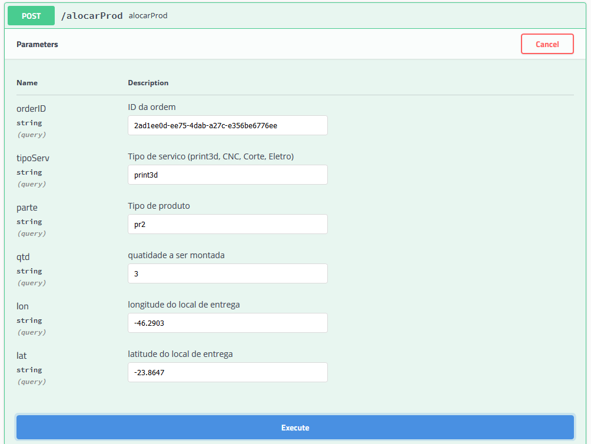

```
{
  "orderInfo": {
    "orderID": "2ad1ee0d-ee75-4dab-a27c-e356be6776ee",
    "parte": "pr2",
    "quantitade": "3"
  },
  "resultado": [
    {
      "centroProd": "BARUERI / OSASCO",
      "tempoProd": 617.2289,
      "tempoFila": 93.8625,
      "tempoViagem": 5667.82,
      "tempoTotal": 5761.6825
    },
    {
      "centroProd": "NITEROI",
      "tempoProd": 617.2289,
      "tempoFila": 92.5259,
      "tempoViagem": 22849.43,
      "tempoTotal": 22941.9559
    },
    {
      "centroProd": "FOZ DO IGUAÇU",
      "tempoProd": 617.2289,
      "tempoFila": 117.0917,
      "tempoViagem": 25443.51,
      "tempoTotal": 25560.6017
    },
    {
      "centroProd": "CASCAVEL",
      "tempoProd": 617.2289,
      "tempoFila": 107.8459,
      "tempoViagem": 42238.02,
      "tempoTotal": 42345.8659
    },
    {
      "centroProd": "BRASILIA",
      "tempoProd": 617.2289,
      "tempoFila": 90.4761,
      "tempoViagem": 46295.12,
      "tempoTotal": 46385.5961
    }
  ]
}
```

## 3. Sistema de log da aplicação

Foi implementado de forma auxiliar um método para recuperar os logs de execução da aplicação, está implementação está em fase inicial e tem como objetivo o tratamento de erros futuros. A recuperação de logs através do **GET** implementada ainda precisa de ajustes para o tratamento e formatação das informações de log geradas.

## 4. Integração com a plataforma WEB

*Próximo passo a ser realizado*

**Ícaro Agostino** `[icaroagostino@gmail.com]`  
**Sistemas Produtivos e Logísticos Inteligentes - ProLogIS/UFSC**